# 11 Polynomials

With the basic properties of functions have been discussed, we move to various types of related functions beginning with polynomial functions.

In this section we use the following add-on packages:

```julia
using SymPy
using Plots
plotly();
```

Polynomials are a particular class of expressions that are simple enough to have many properties that can be analyzed. In particular, the key concepts of calculus: limits, continuity, derivatives, and integrals are all relatively straightforward for polynomial functions. However, polynomials are flexible enough that they can be used to approximate a wide variety of functions. Indeed, though we don’t pursue this, we mention that `Julia`’s `ApproxFun` package exploits this to great advantage.

Here we discuss some vocabulary and basic facts related to polynomials and show how the add-on `SymPy` package can be used to model polynomial expressions within `SymPy`. `SymPy` provides a Computer Algebra System (CAS) for `Julia`. In this case, by leveraging a mature `Python` package [SymPy](https://www.sympy.org/). In the next section we will discuss the `Polynomials` package for representing polynomials.

For our purposes, a *monomial* is simply a non-negative integer power of $x$ (or some other indeterminate symbol) possibly multiplied by a scalar constant. For example, $5x^4$ is a monomial, as are constants, such as $-2$ (it being $-2x^0$) and the symbol $x$ itself (it being $x^1$). In general, one may consider restrictions on where the constants can come from, and consider more than one symbol, but we won’t pursue this here, restricting ourselves to the case of a single variable and real coefficients.

A *polynomial* is a sum of monomials. After combining terms with same powers, a non-zero polynomial may be written uniquely as:

$$a_n x^n + a_{n-1}x^{n-1} + \cdots + a_1 x + a_0, \quad a_n \neq 0$$

The zero polynomial is just $0$.

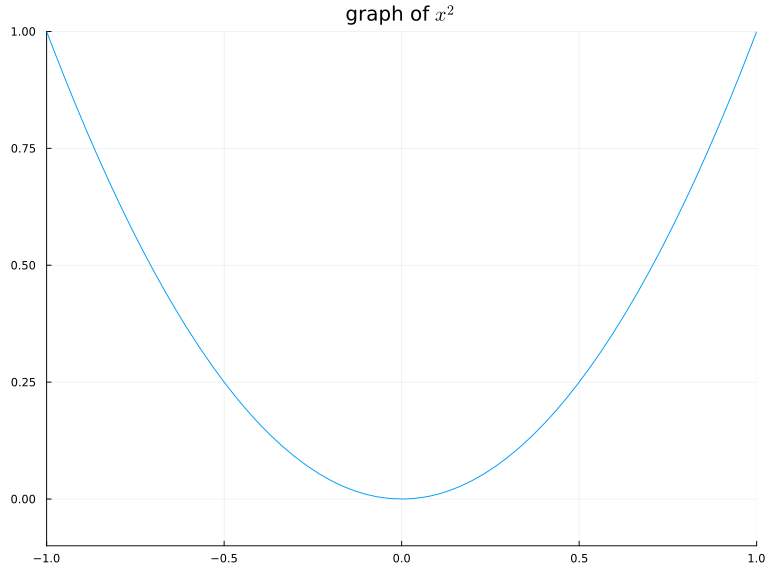

Figure 11.1: Polynomials of varying even degrees over $[-1,1]$

The numbers $a_0, a_1, \dots, a_n$ are the *coefficients* of the polynomial in the standard basis. With the identifications that $x=x^1$ and $1 = x^0$, the monomials above have their power match their coefficient’s index, e.g., $a_ix^i$. Outside of the coefficient $a_n$, the other coefficients may be negative, positive, *or* $0$. Except for the zero polynomial, the largest power $n$ is called the [degree](https://en.wikipedia.org/wiki/Degree_of_a_polynomial). The degree of the [zero](http://tinyurl.com/he6eg6s) polynomial is typically not defined or defined to be $-1$, so as to make certain statements easier to express. The term $a_n$ is called the *leading coefficient*. When the leading coefficient is $1$, the polynomial is called a *monic polynomial*. The monomial $a_n x^n$ is the *leading term*.

For example, the polynomial $-16x^2 - 32x + 100$ has degree $2$, leading coefficient $-16$ and leading term $-16x^2$. It is not monic, as the leading coefficient is not $1$.

Lower degree polynomials have special names: a degree $0$ polynomial ($a_0$) is a non-zero constant, a degree $1$ polynomial ($a_0+a_1x$) is called linear, a degree $2$ polynomial is quadratic, and a degree $3$ polynomial is called cubic.

## 11.1 Linear polynomials

A special place is reserved for polynomials with degree $1$. These are linear, as their graphs are straight lines. The general form,

$$a_1 x + a_0, \quad a_1 \neq 0,$$

is often written as $mx + b$, which is the *slope-intercept* form. The slope of a line determines how steeply it rises. The value of $m$ can be found from two points through the well-known formula:

$$m = \frac{y_1 - y_0}{x_1 - x_0} = \frac{\text{rise}}{\text{run}}$$

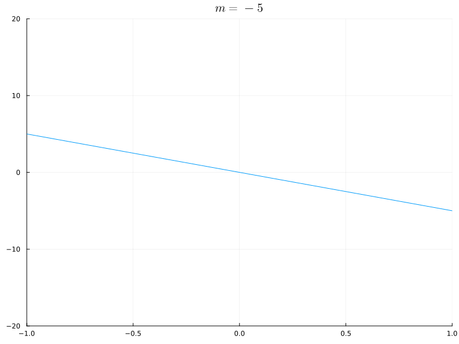

Figure 11.2: Graphs of y = mx for different values of m

The intercept, $b$, comes from the fact that when $x=0$ the expression is $b$. That is, the graph of the function $f(x) = mx + b$ will have $(0,b)$ as a point on it.

More generally, we have the *point-slope* form of a line, written as a polynomial through

$$y_0 + m \cdot (x - x_0).$$

The slope is $m$ and the point $(x_0, y_0)$. Again, the line graphing this as a function of $x$ would have the point $(x_0,y_0)$ on it and have slope $m$. This form is more useful in calculus, as the information we have convenient is more likely to be related to a specific value of $x$, not the special value $x=0$.

Thinking in terms of transformations, this looks like the function $f(x) = x$ (whose graph is a line with slope $1$) stretched in the $y$ direction by a factor of $m$ then shifted right by $x_0$ units, and then shifted up by $y_0$ units. When $m>1$, this means the line grows faster. When $m< 0$, the line $f(x)=x$ is flipped through the $x$-axis so would head downwards, not upwards like $f(x) = x$.

## 11.2 Symbolic math in Julia

The indeterminate value `x` (or some other symbol) in a polynomial, is like a variable in a function and unlike a variable in `Julia`. Variables in `Julia` are identifiers, just a means to look up a specific, already determined, value. Rather, the symbol `x` is not yet determined, it is essentially a place holder for a future value. Although we have seen that `Julia` makes it very easy to work with mathematical functions, it is not the case that base `Julia` makes working with expressions of algebraic symbols easy. This makes sense, `Julia` is primarily designed for technical computing, where numeric approaches rule the day. However, symbolic math can be used from within `Julia` through add-on packages.

Symbolic math programs include well-known ones like the commercial programs Mathematica and Maple. Mathematica powers the popular WolframAlpha website, which turns “natural” language into the specifics of a programming language. The open-source [Sage](https://www.sagemath.org/) project is an alternative to these two commercial giants. It includes a wide-range of open-source math projects available within its umbrella framework. A more focused project for symbolic math, is the SymPy Python library. SymPy is also used within Sage. However, SymPy provides a self-contained library that can be used standalone within a Python session.

The [Symbolics](https://github.com/JuliaSymbolics/Symbolics.jl) package for `Julia` provides a “fast and modern CAS for fast and modern language.” It is described further in Symbolics.jl. The [Giac.jl](https://github.com/s-celles/Giac.jl/) package is another alternative.

As `SymPy` has some features not yet implemented in `Symbolics`, we use `SymPy` in these notes. The `PyCall` and `PythonCall` packages are available to glue `Julia` to Python in a seamless manner. These allow the `Julia` package `SymPy` (or `SymPyPythonCall`) to provide functionality from SymPy within `Julia`. (`Giac` calls a `C++` library and is an alternative that may not be easier to install.)

**NoteNote**

When `SymPy` is installed through the package manager, the underlying `Python` libraries will also be installed.

**NoteAlternative**

The Symbolics package is a rapidly developing `Julia`-only package that provides symbolic math options. The [Giac package](https://github.com/s-celles/Giac.jl/) is another good alternative to `SymPy`. Both packages are described further when alternative packages are discussed.

To use `SymPy`, we create symbolic objects to be our indeterminate symbols. The `symbols` function does this. However, we will use the more convenient `@syms` macro front end for `symbols`.

```julia
@syms a, b, c, x::real, zs[1:10]
```

```
(a, b, c, x, Sym{PyCall.PyObject}[zs₁, zs₂, zs₃, zs₄, zs₅, zs₆, zs₇, zs₈, zs₉, zs₁₀])
```

The above shows that multiple symbols can be defined at once. The annotation `x::real` instructs `SymPy` to assume the `x` is real, as otherwise it assumes it is possibly complex. There are many other assumptions that can be made. The `@syms` macro documentation lists them. The `zs[1:10]` “tensor notation” creates a container with $10$ different symbols. The *macro* `@syms` does not need assignment, as the variable(s) are created behind the scenes by the macro.

**NoteNote**

Macros in `Julia` are just transformations of the syntax into other syntax. The leading `@` indicates they behave differently than regular function calls.

The `SymPy` package does three basic things:

- It imports some of the functionality provided by `SymPy`, including the ability to create symbolic variables.
- It add methods for many `Julia` functions to work seamlessly with symbolic expressions. This makes working with polynomials quite natural.
- It gives access to a wide range of SymPy’s functionality through the `sympy` object.

To illustrate, using the just defined `x`, here is how we can create the polynomial $-16x^2 + 100$:

```julia
p = -16x^2 + 100
```

$100 - 16 x^{2}$

That is, the expression is created just as you would create it within a function body. But here the result is still a symbolic object. We have assigned this expression to a variable `p`, and have not defined it as a function `p(x)`. Mentally keeping the distinction between symbolic expressions and functions is very important.

The `typeof` function shows that `p` is of a symbolic type (`Sym`):

```julia
typeof(p)
```

```
Sym{PyCall.PyObject}
```

We can mix and match symbolic objects. This command creates an arbitrary quadratic polynomial:

```julia
quad = a*x^2 + b*x + c
```

$a x^{2} + b x + c$

Again, this is entered in a manner nearly identical to how we see such expressions typeset ($ax^2 + bx+c$), though we must remember to explicitly place the multiplication operator, as the symbols are not numeric literals.

We can apply many of `Julia`’s mathematical functions and the result will still be symbolic:

```julia
sin(a*(x - b*pi) + c)
```

$\sin{\left(a \left(- \pi b + x\right) + c \right)}$

Another example, might be the following combination:

```julia
quad + quad^2 - quad^3
```

$a x^{2} + b x + c - \left(a x^{2} + b x + c\right)^{3} + \left(a x^{2} + b x + c\right)^{2}$

One way to create symbolic expressions is simply to call a `Julia` function with symbolic arguments. The first line in the next example defines a function, the second evaluates it at the symbols `x`, `a`, and `b` resulting in a symbolic expression `ex`:

```julia
f(x, m, b) = m*x + b
ex = f(x, a, b)
```

$a x + b$

## 11.3 Substitution: subs, replace

Algebraically working with symbolic expressions is straightforward. A different symbolic task is substitution. For example, replacing each instance of `x` in a polynomial, with, say, `(x-1)^2`. Substitution requires three things to be specified: an expression to work on, a variable to substitute, and a value to substitute in.

SymPy provides its `subs` function for this. This function is available in `Julia`, but it is easier to use notation reminiscent of function evaluation.

To illustrate, to do the task above for the polynomial $-16x^2 + 100$ we could have:

```julia
p(x => (x-1)^2)
```

$100 - 16 \left(x - 1\right)^{4}$

This “call” notation takes pairs (designated by `a=>b`) where the left-hand side is the variable to substitute for, and the right-hand side the new value. (This mirrors a similar use with `replace`.) The value to substitute can depend on the variable, as illustrated; be a different variable; or be a numeric value, such as $2$:

```julia
y = p(x=>2)
```

$36$

The result will always be of a symbolic type, even if the answer is just a number:

```julia
typeof(y)
```

```
Sym{PyCall.PyObject}
```

##### Example

Suppose we have the polynomial $p = ax^2 + bx +c$. What would it look like if we shifted right by $E$ units and up by $F$ units?

```julia
@syms E F
p = a*x^2 + b*x + c
p(x => x-E) + F
```

$F + a \left(- E + x\right)^{2} + b \left(- E + x\right) + c$

And expanded this becomes:

```julia
expand(p(x => x-E) + F)
```

$E^{2} a - 2 E a x - E b + F + a x^{2} + b x + c$

### 11.3.1 Conversion of symbolic numbers to Julia numbers

In the above, we substituted `2` in for `x` to get `y`:

```julia
p = -16x^2 + 100
y = p(x => 2)
```

$36$

The value, $36$ is still symbolic, but clearly an integer. If we are just looking at the output, we can easily translate from the symbolic value to an integer, as they print similarly. However the conversion to an integer, or another type of number, does not happen automatically. If a number is needed to pass along to another `Julia` function, it may need to be converted. In general, conversions between different types are handled through various methods of `convert`.

For real numbers, an easy to call conversion is available through the generic `float` method, which converts a value to a floating point type::

```julia
float(y)
```

```
36.0
```

`SymPy` objects have their own internal types. To preserve these on conversion to a related `Julia` value, the `N` function from `SymPy` is useful:

```julia
p = -16x^2 + 100
N(p(x=>2))
```

```
36
```

Where `convert(T, x)` requires a specification of the type to convert `x` to, `N` attempts to match the data type used by SymPy to store the number. As such, the output type of `N` may vary (rational, a BigFloat, a float, etc.) Conversion by `N` will fail if the value to be converted contains free symbols, as would be expected.

### 11.3.2 Converting symbolic expressions into Julia functions

Evaluating a symbolic expression and returning a numeric value can be done by composing the two just discussed concepts. For example:

```julia
p = 200 - 16x^2
N(p(x=>2))
```

```
136
```

This approach is direct, but can be slow *if* many such evaluations were needed (such as with a plot). An alternative is to turn the symbolic expression into a `Julia` function and then evaluate that as usual.

The `lambdify` function turns a symbolic expression into a `Julia` function

```julia
pp = lambdify(p)
pp(2)
```

```
136
```

The `lambdify` function uses the name of the similar `SymPy` function which is named after Python’s convention of calling anonymous function “lambdas.” The use above is straightforward. Only slightly more complicated is the use when there are multiple symbolic values. For example:

```julia
p = a*x^2 + b
pp = lambdify(p)
pp(1,2,3)
```

```
11
```

This evaluation matches `a` with `1`, `b` with`2`, and `x` with `3` as that is the order returned by the function call `free_symbols(p)`. Leaving the order to an underlying function is not a great idea, rather, explicitly passing the variables is recommended:

```julia
pp = lambdify(p, (x,a,b))      # specify the variables
pp(1,2,3) # computes 2*1^2 + 3
```

```
5
```

## 11.4 Graphical properties of polynomials

Consider the graph of the polynomial `x^5 - x + 1` in Figure 11.3:

```julia
plot(x^5 - x + 1, -3/2, 3/2)
```

[output not shown]

Figure 11.3: Plot of $f(x) = x^5 - x + 1$ using the recipe for `SymPy` expression

(Plotting symbolic expressions with `Plots` is similar to plotting a function, in that the expression is passed in as the first argument. The expression must have only one free variable, as above, or an error will occur. This happens, as there is a `Plots` “recipe” for `SymPy` defined.)

This graph illustrates the key features of polynomial graphs:

- there may be values for `x` where the graph crosses the $x$ axis (real roots of the polynomial);
- there may be peaks and valleys (local maxima and local minima);
- except for constant polynomials, the ultimate behaviour for large values of $|x|$ is either both sides of the graph going to positive infinity, or negative infinity, or as in this graph one to the positive infinity and one to negative infinity. In particular, there is no *horizontal asymptote*.

To investigate this last point, let’s consider the case of the monomial $x^n$. When $n$ is even, the animation in Figure 11.4 shows that larger values of $n$ have greater growth once outside of $[-1,1]$:

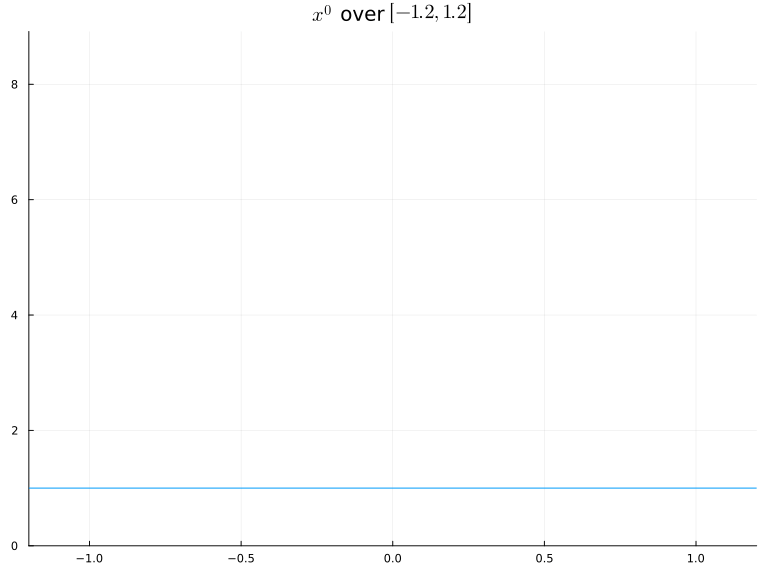

Figure 11.4: Demonstration that $x^{10}$ grows faster than $x^8$, $\dots$, and $x^2$ grows faster than $x^0$ (which is constant)

Of course, this is expected, as, for example, $2^2 < 2^4 < 2^6 < \cdots$. The general shape of these terms is similar—$U$ shaped, and larger powers dominate the smaller powers as $|x|$ gets big.

For odd powers of $n$, the graph of the monomial $x^n$ is no longer $U$ shaped, but rather constantly increasing. This graph of $x^5$ is typical; for larger powers the shape is similar, but the growth is faster.

```julia
plot(x^5, -2, 2)
```

[output not shown]

Figure 11.5: Plot of odd degree monomial showing the general shape for large $x$.

### 11.4.1 Leading term dominates

To see the roots and/or the peaks and valleys of a polynomial requires a judicious choice of viewing window, as ultimately the leading term will dominate the graph. Figure 11.6 shows the graph of the fourth-degree polynomial $(x-5)(x-3)(x-2)(x-1)$ over different domains. Subsequent images show a widening of the plot window until the graph appears U-shaped. The leading term in the animation is $x^4$, of even degree, so the graphic is U-shaped, were the leading term of odd degree the left and right sides would each head off to different signs of infinity.

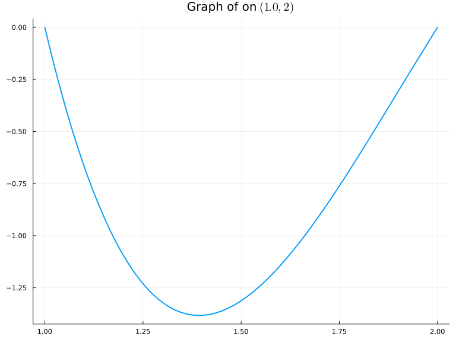

Figure 11.6: The previous graph is highlighted in red. Ultimately the leading term ($x^4$ here) dominates the graph.

To illustrate analytically why the leading term dominates, consider the polynomial $2x^5 - x + 1$ and then factor out the largest power, $x^5$, leaving a product:

$$x^5 \cdot (2 - \frac{1}{x^4} + \frac{1}{x^5}).$$

For large $|x|$, the last two terms in the product on the right get close to $0$, so this expression is *basically* just $2x^5$—the leading term.

Figure 11.7 illustrates the $4$ basic *overall* shapes that can result when plotting a polynomials as $x$ grows without bound:

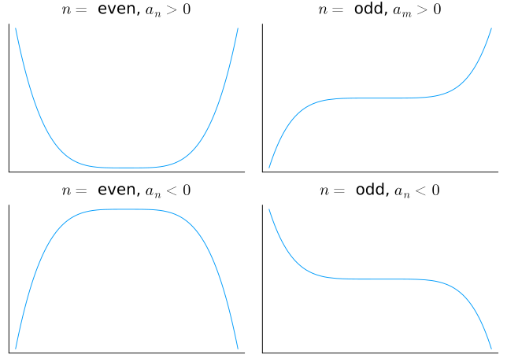

Figure 11.7: Figure illustrating the four basic shapes a polynomial may take for large values of $x$ or $-x$.

##### Example

Suppose $p = a_n x^n + \cdots + a_1 x + a_0$ with $a_n > 0$. Then by the above, eventually for large $x > 0$ we have $p > 0$, as that is the behaviour of $a_n x^n$. Were $a_n < 0$, then eventually for large $x>0$, $p < 0$.

Now consider the related polynomial, $q$, where we multiply $p$ by $x^n$ and substitute in $1/x$ for $x$. This is the “reversed” polynomial, as we see in this illustration for $n=2$:

```julia
p = a*x^2 + b*x + c
n = 2    # the degree of p
expand(x^n * p(x => 1/x))
```

$a + b x + c x^{2}$

In particular, from the reversal, the behavior of $q$ for large $x$ depends on the sign of $a_0$. As well, due to the $1/x$, the behaviour of $q$ for large $x>0$ is the same as the behaviour of $p$ for small *positive* $x$. In particular if $a_n > 0$ but $a_0 < 0$, then `p` is eventually positive and `q` is eventually negative.

That is, if $p$ has $a_n > 0$ but $a_0 < 0$ then the graph of $p$ must cross the $x$ axis.

This observation is the start of Descartes’ rule of [signs](http://sepwww.stanford.edu/oldsep/stew/descartes.pdf), which counts the change of signs of the coefficients in `p` to say something about how many possible crossings there are of the $x$ axis by the graph of the polynomial $p$.

## 11.5 Factoring polynomials

Among others, there are two common ways of representing a non-zero polynomial:

- expanded form, as in $a_n x^n + a_{n-1}x^{n-1} + \cdots + a_1 x + a_0,\quad a_n \neq 0$; or
- factored form, as in $a\cdot(x-r_1)\cdot(x-r_2)\cdots(x-r_n), \quad a \neq 0$.

The former uses the *standard basis* to represent the polynomial $p$. The latter writes $p$ as a product of linear factors, though this is only possible in general if we consider complex roots. With real roots only, then the factors are either linear or quadratic, as will be discussed later.

There are values to each representation. One value of the expanded form is that polynomial addition and scalar multiplication is much easier than in factored form. For example, adding polynomials just requires matching up the monomials of similar powers. For the factored form, polynomial multiplication is much easier than expanded form. For the factored form it is easy to read off *roots* of the polynomial (values of $x$ where $p$ is $0$), as a product is $0$ only if a term is $0$, so any zero must be a zero of a factor. Factored form has other technical advantages. For example, the polynomial $(x-1)^{1000}$ can be compactly represented using the factored form, but would require $1001$ coefficients to store in expanded form. (As well, due to floating point differences, the two would evaluate quite differently as one would require over a $1000$ operations to compute, the other just two.)

Translating from factored form to expanded form can be done by carefully following the distributive law of multiplication. For example, with some care it can be shown that:

$$(x-1) \cdot (x-2) \cdot (x-3) = x^3 - 6x^2 +11x - 6.$$

The `SymPy` function `expand` will perform these algebraic manipulations without fuss:

```julia
expand((x-1)*(x-2)*(x-3))
```

$x^{3} - 6 x^{2} + 11 x - 6$

Factoring a polynomial is several weeks worth of lessons, as there is no one-size-fits-all algorithm available to teach to algebra students. There are some tricks that are taught: for example factoring differences of perfect squares, completing the square, the rational root theorem, $\dots$. But in general the solution is not automated without some more advanced techniques. The `SymPy` function `factor` will find all rational factors (terms like $(qx-p)$), but will leave terms that do not have rational factors alone. For example:

```julia
factor(x^3 - 6x^2 + 11x -6)
```

$\left(x - 3\right) \left(x - 2\right) \left(x - 1\right)$

Or

```julia
factor(x^5 - 5x^4 + 8x^3 - 8x^2 + 7x - 3)
```

$\left(x - 3\right) \left(x - 1\right)^{2} \left(x^{2} + 1\right)$

But will not factor things that are not hard to see:

```julia
factor(x^2 - 2)
```

$x^{2} - 2$

The factoring $(x-\sqrt{2})\cdot(x + \sqrt{2})$ is not found, as $\sqrt{2}$ is not rational.

(For those, it may be possible to solve to get the roots, which can then be used to produce the factored form.)

### 11.5.1 Polynomial functions and polynomials.

Our definition of a polynomial is in terms of algebraic expressions which are easily represented by `SymPy` objects, but not objects from base `Julia`. However, *polynomial functions* are easily represented by `Julia`, for example:

```julia
f(x) = -16x^2 + 100
```

```
f (generic function with 2 methods)
```

The distinction is subtle, the expression is turned into a function just by adding the “`f(x) =`” preface. But to `Julia` there is a big distinction. The function form never does any computation until after a value of $x$ is passed to it. Whereas symbolic expressions can be manipulated quite freely before any numeric values are specified.

It is easy to create a symbolic expression from a function—just evaluate the function on a symbolic value:

```julia
f(x)
```

$100 - 16 x^{2}$

This is easy—but can also be confusing. The function object is `f`, the expression is `f(x)`—the function evaluated on a symbolic object.

For many uses, the distinction is unnecessary to make, as the many functions will work with any callable expression. For `Plots` there is a recipe—either `plot(f, a, b)` or `plot(f(x), a, b)` will produce the same plot using the `Plots` package.

## 11.6 Questions

###### Question

Let $p$ be the polynomial $3x^2 - 2x + 5$.

What is the degree of $p$?

What is the leading coefficient of $p$?

The graph of $p$ would have what $y$-intercept?

Is $p$ a monic polynomial?

Yes

No

Is $p$ a quadratic polynomial?

Yes

No

The graph of $p$ would be $U$-shaped?

Yes

No

What is the leading term of $p$?

###### Question

Let $p = x^3 - 2x^2 +3x - 4$.

What is $a_2$, using the standard numbering of coefficient?

What is $a_n$?

What is $a_0$?

###### Question

The linear polynomial $p = 2x + 3$ is written in which form:

###### Question

The polynomial `p` is defined in `Julia` as follows:

```julia
@syms x
p = -16x^2 + 64
```

What command will return the value of the polynomial when $x=2$?

###### Question

In the large, the graph of $p=x^{101} - x + 1$ will

Be \(U\)-shaped, opening upward

Be \(U\)-shaped, opening downward

Overall, go upwards from \(-\infty\) to \(+\infty\)

Overall, go downwards from \(+\infty\) to \(-\infty\)

###### Question

In the large, the graph of $p=x^{102} - x^{101} + x + 1$ will

Be \(U\)-shaped, opening upward

Be \(U\)-shaped, opening downward

Overall, go upwards from \(-\infty\) to \(+\infty\)

Overall, go downwards from \(+\infty\) to \(-\infty\)

###### Question

In the large, the graph of $p=-x^{10} + x^9 + x^8 + x^7 + x^6$ will

Be \(U\)-shaped, opening upward

Be \(U\)-shaped, opening downward

Overall, go upwards from \(-\infty\) to \(+\infty\)

Overall, go downwards from \(+\infty\) to \(-\infty\)

###### Question

Use `SymPy` to factor the polynomial $x^{11} - x$. How many factors are found?

###### Question

Use `SymPy` to factor the polynomial $x^{12} - 1$. How many factors are found?

###### Question

What is the monic polynomial with roots $x=-1$, $x=0$, and $x=2$?

###### Question

Use `expand` to expand the expression `((x-h)^3 - x^3) / h` where `x` and `h` are symbolic constants. What is the value: